# neurodegeneration

Brian M. Schilder

2023-03-21

Trying to have another look through our results for anything neurodegeneration-related, either at the level of phenotype or disease.

# Import results

```r
res <- MultiEWCE::load_example_results()
annot <- HPOExplorer::load_phenotype_to_genes(3)
```

```
## Importing existing file: ... phenotype.hpoa
```

## Alzheimer’s

AD is not enriched for any phenotype, likely due to the small number of genes included. GWAS results are more comprehensive than this. https://hpo.jax.org/app/browse/term/HP:0002511

```r
ad <- res[grepl("alzheimer",Phenotype,ignore.case = TRUE)]
nrow(ad) ## 77 results (1 per celltype)
```

```
## [1] 77
```

```r
ad_sig <- ad[q<0.05]
nrow(ad_sig) ## 0 sig results
```

```
## [1] 0
```

```r
MultiEWCE::create_dt(ad_sig)
```

|  | HPO_ID | CellType | annotLevel | p | fold_change | sd_from_mean | Phenotype | q |
| --- | --- | --- | --- | --- | --- | --- | --- | --- |

## Phenotypes

“Parkinson’s disease” is not in the HPO, but the branch “Parkinsonism” is. https://hpo.jax.org/app/browse/term/HP:0001300

We actually do have 2 sig phenotypes here.

```r
pd_phenos <- HPOExplorer::make_phenos_dataframe(ancestor="Parkinsonism")
```

```
## Importing existing file: ... phenotype_to_genes.txt
```

```
## Extracting data for 2 descendents.
```

```
## Computing gene counts.
```

```
## Getting absolute ontology level for 2 HPO IDs.
```

```
## Computing ontology level / gene count ratio.
```

```
## Adding information_content scores.
```

```
## Adding term definitions.
```

```
## Adding level-3 ancestor to each HPO ID.
```

```
## Making hoverboxes from: 'Phenotype', 'HPO_ID', 'ontLvl', 'ontLvl_geneCount_ratio', 'definition', 'ancestor', 'ancestor_name'
```

```r
pd1 <- res[HPO_ID %in% pd_phenos$HPO_ID & q<0.05]

MultiEWCE::create_dt(pd1)
```

|  | HPO_ID | CellType | annotLevel | p | fold_change | sd_from_mean | Phenotype | q |
| --- | --- | --- | --- | --- | --- | --- | --- | --- |
| 1 | HP:0001300 | Ganglion cells | 1 | 0.00016 | 1.63819506904822 | 4.61370561634284 | Parkinsonism | 0.0125166820276498 |
| 2 | HP:0001300 | Limbic system neurons | 1 | 0.00085 | 1.59411667177433 | 3.99131341017833 | Parkinsonism | 0.0486247262005055 |
| 3 | HP:0002548 | Sympathoblasts | 1 | 0.00032 | 4.6214782709248 | 7.53112151442206 | Parkinsonism with favorable response to dopaminergic medication | 0.0221594871794872 |

## Diseases

We can also search for phenotypes via “Parkinson’s” as a disease.

This gives us lots of phenotypes, but many of them are not specific to PD: e.g. *Autosomal recessive inheritance*, *Open mouth*, *Macrocephaly*, *Urinary urgency*

```r
d <- annot[grepl("parkinson",DiseaseName, ignore.case = TRUE)]
pd <- res[HPO_ID %in% d$HPO_ID & q<0.05]

MultiEWCE::create_dt(pd)
```

|  | HPO_ID | CellType | annotLevel | p | fold_change | sd_from_mean | Phenotype | q |
| --- | --- | --- | --- | --- | --- | --- | --- | --- |
| 1 | HP:0000006 | Cardiomyocytes | 1 | 4e-05 | 1.17100320420736 | 3.99172907969658 | Autosomal dominant inheritance | 0.00381171611868484 |
| 2 | HP:0000006 | Excitatory neurons | 1 | 5e-05 | 1.11396510323772 | 3.83784469061235 | Autosomal dominant inheritance | 0.00463637339055794 |
| 3 | HP:0000006 | Inhibitory neurons | 1 | 0.00023 | 1.10695035551756 | 3.25579937798808 | Autosomal dominant inheritance | 0.0168787756677474 |
| 4 | HP:0000006 | Lens fibre cells | 1 | 4e-05 | 1.37319214919816 | 4.12807227439027 | Autosomal dominant inheritance | 0.00381171611868484 |
| 5 | HP:0000006 | SATB2 LRRC7 positive cells | 1 | 0 | 1.15952998707048 | 4.31437390334422 | Autosomal dominant inheritance | 0 |
| 6 | HP:0000006 | Skeletal muscle cells | 1 | 0.00062 | 1.23619747473473 | 3.29200153381306 | Autosomal dominant inheritance | 0.0377722404511664 |
| 7 | HP:0000006 | Smooth muscle cells | 1 | 0.00055 | 1.12412461814551 | 3.31211224065749 | Autosomal dominant inheritance | 0.0343891804788214 |
| 8 | HP:0000007 | AFP ALB positive cells | 1 | 0 | 1.19206605249699 | 4.52284113618398 | Autosomal recessive inheritance | 0 |
| 9 | HP:0000007 | Adrenocortical cells | 1 | 0.00023 | 1.08660882607828 | 3.39518223877231 | Autosomal recessive inheritance | 0.0168787756677474 |
| 10 | HP:0000007 | Ciliated epithelial cells | 1 | 0 | 1.21070651771536 | 5.00406404331296 | Autosomal recessive inheritance | 0 |

[output cut: 1060 more lines]

Let’s try to narrow it down to very PD-specific phenotypes.

These PD-associated phenotypes only appear once in the HPO annotations. Thus, they must be PD-specific.

That leaves us with just 2 phenotypes.

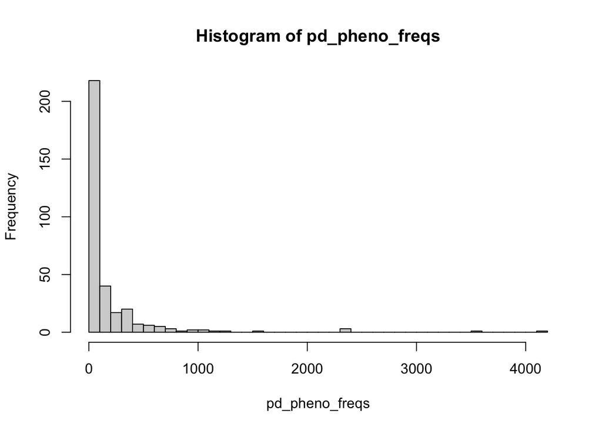

```r
n_pd_terms <- length(unique(pd_phenos$HPO_ID))
pd_pheno_freqs <- sort(table(annot[HPO_ID %in% d$HPO_ID]$HPO_ID))
hist(pd_pheno_freqs, 50)
```

```r
pd_specific <- pd[HPO_ID %in% names(pd_pheno_freqs)[pd_pheno_freqs<=1+n_pd_terms]]

MultiEWCE::create_dt(pd_specific)
```

|  | HPO_ID | CellType | annotLevel | p | fold_change | sd_from_mean | Phenotype | q |
| --- | --- | --- | --- | --- | --- | --- | --- | --- |
| 1 | HP:0004354 | AFP ALB positive cells | 1 | 0 | 2.86881720595541 | 8.16571079982305 | Abnormal circulating carboxylic acid concentration | 0 |
| 2 | HP:0004354 | Erythroblasts | 1 | 0 | 2.9514078293658 | 9.96810061680193 | Abnormal circulating carboxylic acid concentration | 0 |
| 3 | HP:0004354 | Hepatoblasts | 1 | 0 | 3.73150395403014 | 12.499835042862 | Abnormal circulating carboxylic acid concentration | 0 |
| 4 | HP:0025456 | Schwann cells | 1 | 0.00035 | 3.21289518894354 | 7.22231345814524 | Abnormal CSF protein level | 0.0238683428981349 |

We can lift this filter a bit and look for PD-associated phenotypes that only appear in 5 or less non-PD diseases. We see phenotype that can indeed be associated with PD, but are not necessarilly exclusive to it: e.g. *Diminished movement*, *Abnormal aggressive, impulsive or violent behavior*, *Abnormal nervous system physiology*

```r
pd_specific2 <- pd[HPO_ID %in% names(pd_pheno_freqs)[pd_pheno_freqs<=5+n_pd_terms]]
MultiEWCE::create_dt(pd_specific2)
```

|  | HPO_ID | CellType | annotLevel | p | fold_change | sd_from_mean | Phenotype | q |
| --- | --- | --- | --- | --- | --- | --- | --- | --- |
| 1 | HP:0002374 | Satellite cells | 1 | 3e-05 | 3.38684757818629 | 7.91090351674178 | Diminished movement | 0.00295291571753986 |
| 2 | HP:0002374 | Skeletal muscle cells | 1 | 0 | 6.79564374686194 | 12.1098768093994 | Diminished movement | 0 |
| 3 | HP:0004354 | AFP ALB positive cells | 1 | 0 | 2.86881720595541 | 8.16571079982305 | Abnormal circulating carboxylic acid concentration | 0 |
| 4 | HP:0004354 | Erythroblasts | 1 | 0 | 2.9514078293658 | 9.96810061680193 | Abnormal circulating carboxylic acid concentration | 0 |
| 5 | HP:0004354 | Hepatoblasts | 1 | 0 | 3.73150395403014 | 12.499835042862 | Abnormal circulating carboxylic acid concentration | 0 |
| 6 | HP:0004673 | Skeletal muscle cells | 1 | 0 | 3.94789814188328 | 8.19056750545151 | Decreased facial expression | 0 |
| 7 | HP:0006919 | Amacrine cells | 1 | 0 | 1.55363069137574 | 7.0248412296251 | Abnormal aggressive, impulsive or violent behavior | 0 |
| 8 | HP:0006919 | Chromaffin cells | 1 | 0.00038 | 1.38798724159992 | 4.00829518267485 | Abnormal aggressive, impulsive or violent behavior | 0.0255187877931619 |
| 9 | HP:0006919 | Excitatory neurons | 1 | 0 | 1.90194370960909 | 10.088689535516 | Abnormal aggressive, impulsive or violent behavior | 0 |
| 10 | HP:0006919 | Ganglion cells | 1 | 0 | 1.56702014625821 | 7.00222391255408 | Abnormal aggressive, impulsive or violent behavior | 0 |

[output cut: 37 more lines]

## Mental deterioration

Get all the phenos from the Mental deterioration branch. This includes many forms of dementia https://hpo.jax.org/app/browse/term/HP:0001268

```r
phenos <- HPOExplorer::make_phenos_dataframe(ancestor="Mental deterioration")
```

```
## Importing existing file: ... phenotype_to_genes.txt
```

```
## Extracting data for 14 descendents.
```

```
## Computing gene counts.
```

```
## Getting absolute ontology level for 14 HPO IDs.
```

```
## Computing ontology level / gene count ratio.
```

```
## Adding information_content scores.
```

```
## Adding term definitions.
```

```
## Adding level-3 ancestor to each HPO ID.
```

```
## Making hoverboxes from: 'Phenotype', 'HPO_ID', 'ontLvl', 'ontLvl_geneCount_ratio', 'definition', 'ancestor', 'ancestor_name'
```

```r
md <- res[HPO_ID %in% phenos$HPO_ID & q<0.05]

MultiEWCE::create_dt(md)
```

|  | HPO_ID | CellType | annotLevel | p | fold_change | sd_from_mean | Phenotype | q |
| --- | --- | --- | --- | --- | --- | --- | --- | --- |
| 1 | HP:0000727 | Microglia | 1 | 9e-05 | 6.22097948470194 | 8.30603642479423 | Frontal lobe dementia | 0.00771346736386585 |
| 2 | HP:0001268 | Amacrine cells | 1 | 0.00017 | 1.33222258198051 | 4.1882659462883 | Mental deterioration | 0.0131624971493729 |
| 3 | HP:0001268 | Excitatory neurons | 1 | 0.00017 | 1.39309616224648 | 4.39549036337286 | Mental deterioration | 0.0131624971493729 |
| 4 | HP:0001268 | Ganglion cells | 1 | 0.00041 | 1.32149295954168 | 3.941458354996 | Mental deterioration | 0.0271536310436115 |
| 5 | HP:0001268 | Inhibitory neurons | 1 | 1e-05 | 1.53608108799096 | 5.38463914573892 | Mental deterioration | 0.00109748556915262 |
| 6 | HP:0001268 | Limbic system neurons | 1 | 2e-05 | 1.45867795989447 | 5.21929525282227 | Mental deterioration | 0.00206347297590623 |
| 7 | HP:0001268 | Purkinje neurons | 1 | 0.00047 | 1.40896105471863 | 3.92131505573633 | Mental deterioration | 0.0303245378037193 |
| 8 | HP:0001268 | SKOR2 NPSR1 positive cells | 1 | 0.00056 | 1.40564858480159 | 3.86695252168408 | Mental deterioration | 0.0349088209836066 |
| 9 | HP:0001268 | SLC24A4 PEX5L positive cells | 1 | 0.0007 | 1.36471430219847 | 3.83045178144475 | Mental deterioration | 0.0416843773490353 |

## Atrophy/Degeneration affecting the central nervous system

HPO has the term: **Atrophy/Degeneration affecting the central nervous system** https://hpo.jax.org/app/browse/term/HP:0007367

In our results, we found a number of significantly enriched phenotypes that fall under that branch:

```r
phenos <- HPOExplorer::make_phenos_dataframe(ancestor="Atrophy/Degeneration affecting the central nervous system")
```

```
## Importing existing file: ... phenotype_to_genes.txt
```

```
## Extracting data for 41 descendents.
```

```
## Computing gene counts.
```

```
## Getting absolute ontology level for 41 HPO IDs.
```

```
## Computing ontology level / gene count ratio.
```

```
## Adding information_content scores.
```

```
## Adding term definitions.
```

```
## Adding level-3 ancestor to each HPO ID.
```

```
## Making hoverboxes from: 'Phenotype', 'HPO_ID', 'ontLvl', 'ontLvl_geneCount_ratio', 'definition', 'ancestor', 'ancestor_name'
```

```r
at <- res[HPO_ID %in% phenos$HPO_ID & q<0.05]
MultiEWCE::create_dt(at)
```

|  | HPO_ID | CellType | annotLevel | p | fold_change | sd_from_mean | Phenotype | q |
| --- | --- | --- | --- | --- | --- | --- | --- | --- |
| 1 | HP:0002059 | Amacrine cells | 1 | 0 | 1.39986212366739 | 7.32750144684806 | Cerebral atrophy | 0 |
| 2 | HP:0002059 | Excitatory neurons | 1 | 0 | 1.51875464526551 | 8.42382972752351 | Cerebral atrophy | 0 |
| 3 | HP:0002059 | Ganglion cells | 1 | 0 | 1.3919057757736 | 7.02993611256756 | Cerebral atrophy | 0 |
| 4 | HP:0002059 | Granule neurons | 1 | 0 | 1.51674423991736 | 6.39413555942339 | Cerebral atrophy | 0 |
| 5 | HP:0002059 | Inhibitory interneurons | 1 | 1e-05 | 1.48402522332233 | 4.9936958910583 | Cerebral atrophy | 0.00109748556915262 |
| 6 | HP:0002059 | Inhibitory neurons | 1 | 0 | 1.52061019386082 | 7.620926074022 | Cerebral atrophy | 0 |
| 7 | HP:0002059 | Limbic system neurons | 1 | 0 | 1.5783898813633 | 9.62922003399206 | Cerebral atrophy | 0 |
| 8 | HP:0002059 | Oligodendrocytes | 1 | 1e-05 | 1.38756490638805 | 4.85531206900936 | Cerebral atrophy | 0.00109748556915262 |
| 9 | HP:0002059 | Purkinje neurons | 1 | 0 | 1.43324252911624 | 6.06548250392627 | Cerebral atrophy | 0 |
| 10 | HP:0002059 | SATB2 LRRC7 positive cells | 1 | 0 | 1.51705535687353 | 6.74536890476855 | Cerebral atrophy | 0 |

[output cut: 56 more lines]